# Problem 16.1 Discoveries data revisited

The file evaluation_discoveries.csv contains data on the numbers of “great” inventions and scientific discoveries ($X_t$) in each year from 1860 to 1959. In this question you will develop a model to explain the variation in scientific inventions over time. The simplest model here is to assume that

1. one discovery is independent of all others, and
2. the rate of occurrence of discoveries is the same in all years ($\lambda$).

Since the data is discrete, these assumptions suggest the use a Poisson likelihood, $X_t ∼ Poisson(\lambda)$.

# Problem 16.1.1.

Open a text editor and create a file called “discoveries.stan” in your working directory. In the file create three parameter blocks:

```
data {

}

parameters {

}

model {

}
```

# Problem 16.1.2.

Fill in the data and parameter blocks for the above model.

# Problem 16.1.3

Using a $log-N( 2,1)$ prior for $\lambda$, code up the model block, making sure to save your file afterwards.

# Problem 16.1.4

Open your statistical software (R, Python, Matlab, and so on) and load any packages necessary to use Stan. (Hint: in R this is done by using library( rstan); in Python this is done using import pystan.)

```r
library(rstan)
library(tidyverse)
```

# Problem 16.1.5

Load the data into your software and then put it into a structure that can be passed to Stan. (Hint: in R create a list of the data; in Python create a dictionary where the ‘key’ for each variable is the desired variable name.)

```r
eval_disc <- readr::read_csv(here::here("STAN", "data", "evaluation_discoveries.csv"))
X <- eval_disc$discoveries
N <- length(X)
```

# Problem 16.1.6

Run your model using Stan, with four chains, each with a sample size of 1000, and a warm-up of 500 samples. Set seed = 1 to allow for reproducibility of your results. Store your result in an object called fit.

```r
set.seed = 1

fit <- stan(here::here("STAN", "problem_16_1", "discoveries.stan"),
            data = list(N = N, X = X),
            iter = 1000,
            chains = 4,
            warmup = 500)
```

```
## recompiling to avoid crashing R session
```

# Problem 16.1.7

Diagnose whether your model has converged by printing fit.

```r
# Lambda and lp should both have a value of Rˆ ≈ 1.
print(fit)
```

```
## Inference for Stan model: discoveries.
## 4 chains, each with iter=1000; warmup=500; thin=1;
## post-warmup draws per chain=500, total post-warmup draws=2000.
##
##         mean se_mean   sd  2.5%   25%   50%   75% 97.5% n_eff Rhat
## lambda  3.11    0.01 0.17  2.80  3.00  3.10  3.22  3.46   754 1.00
## lp__   39.90    0.02 0.65 38.14 39.74 40.16 40.32 40.36   867 1.01
##
## Samples were drawn using NUTS(diag_e) at Sat Oct 17 20:52:54 2020.
## For each parameter, n_eff is a crude measure of effective sample size,
## and Rhat is the potential scale reduction factor on split chains (at
## convergence, Rhat=1).
```

$lambda$ and $lp$ should both have a value of $\hat{R} \approx 1$.

# Problem 16.1.8

# Problem 16.1.9

Find the central posterior 80% credible interval for $\lambda$.

```r
lambda_post <- rstan::extract(fit, 'lambda')[[1]]

# Find the central posterior 80% credible interval for λ.
quantile(lambda_post, probs = c(0.1, 0.9))
```

```
##      10%      90%
## 2.899408 3.336864
```

```r
print(fit, pars='lambda', probs = c(0.1, 0.9))
```

```
## Inference for Stan model: discoveries.
## 4 chains, each with iter=1000; warmup=500; thin=1;
## post-warmup draws per chain=500, total post-warmup draws=2000.
##
##        mean se_mean   sd 10%  90% n_eff Rhat
## lambda 3.11    0.01 0.17 2.9 3.34   754    1
##
## Samples were drawn using NUTS(diag_e) at Sat Oct 17 20:52:54 2020.
## For each parameter, n_eff is a crude measure of effective sample size,
## and Rhat is the potential scale reduction factor on split chains (at
## convergence, Rhat=1).
```

# Problem 16.1.10

Draw a histogram of your posterior samples for $\lambda$.

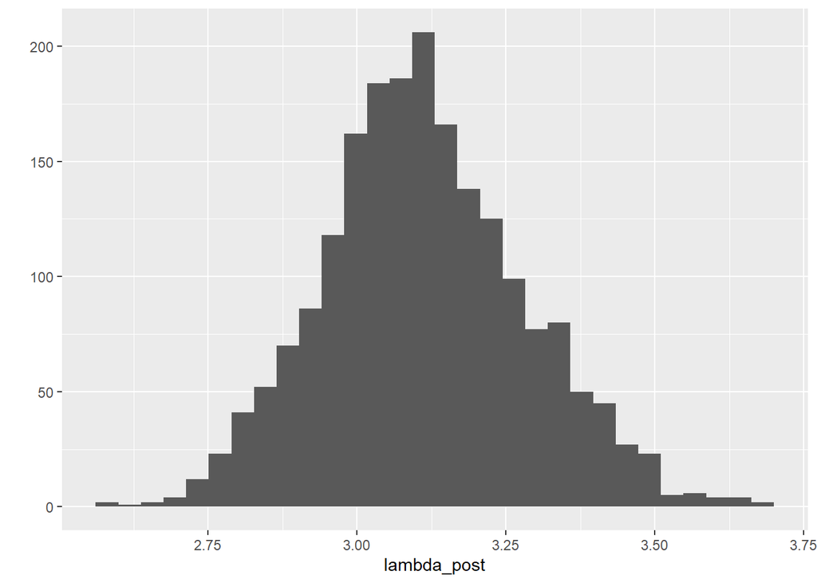

```r
qplot(lambda_post)
```

# Problem 16.1.11

Load the evaluation_discoveries.csv data and graph it. What does this suggest about our model’s assumptions?

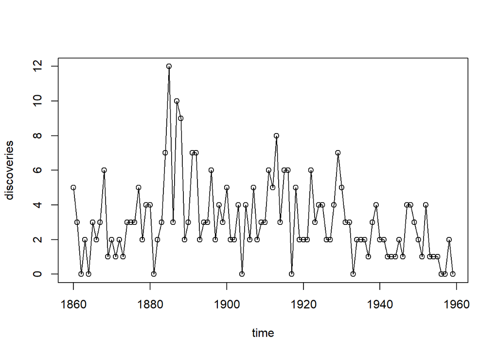

```r
plot(eval_disc, type = "o")
```